# Supervised Machine Learning in Python

## Beatriz Manso

#### Set working directory:

```python
#set working directory
setwd = ("C:/Users/manso/OneDrive - University of West London/MSc Bioinformatics - UWL/3.DSB - Data Science for Bioinformatics/Practice/W12 - Supervised ML in Python")
```

#### Load Libraries:

```python
import pandas as pd
import numpy as np
import seaborn as sns
import matplotlib.pyplot as plt
%matplotlib inline
sns.set(color_codes=True)
from scipy import stats
from sklearn.ensemble import RandomForestClassifier
from sklearn.model_selection import train_test_split, cross_val_score, cross_val_predict
from sklearn import metrics
from sklearn import datasets
from sklearn.linear_model import LogisticRegression
from sklearn.tree import DecisionTreeClassifier
from sklearn import tree
from sklearn.neighbors import KNeighborsClassifier
from sklearn.metrics import confusion_matrix
from sklearn.metrics import classification_report
```

# 1. Load the Data

#### DataSet Description

14 features(Columns) including the target:

- **slope_of_peak_exercise_st_segment** (type: int): the slope of the peak exercise ST segment, an electrocardiography read out indicating quality of blood flow to the heart
- **thal** (type: categorical): results of thallium stress test measuring blood flow to the heart, with possible values normal, fixed_defect, reversible_defect
- **resting_blood_pressure** (type: int): resting blood pressure
- **chest_pain_type** (type: int): chest pain type (4 values)
- **num_major_vessels** (type: int): number of major vessels (0-3) colored by flourosopy
- **fasting_blood_sugar_gt_120_mg_per_dl** (type: binary): fasting blood sugar > 120 mg/dl
- **resting_ekg_results** (type: int): resting electrocardiographic results (values 0,1,2)
- **serum_cholesterol_mg_per_dl** (type: int): serum cholestoral in mg/dl
- **oldpeak_eq_st_depression** (type: float): oldpeak = ST depression induced by exercise relative to rest, a measure of abnormality in electrocardiograms
- **sex** (type: binary): 0: female, 1: male
- **age** (type: int): age in years
- **max_heart_rate_achieved** (type: int): maximum heart rate achieved (beats per minute)
- **exercise_induced_angina** (type: binary): exercise-induced chest pain (0: False, 1: True)

```python
df = pd.read_csv("C:/Users/manso/OneDrive - University of West London/MSc Bioinformatics - UWL/3.DSB - Data Science for Bioinformatics/Practice/DSB W12 - Supervised ML in Python/heart.csv")
```

```python
df.head()
```

|  | age | sex | cp | trestbps | chol | fbs | restecg | thalach | exang | oldpeak | slope | ca | thal | target |
| --- | --- | --- | --- | --- | --- | --- | --- | --- | --- | --- | --- | --- | --- | --- |
| 0 | 63 | 1 | 3 | 145 | 233 | 1 | 0 | 150 | 0 | 2.3 | 0 | 0 | 1 | 1 |
| 1 | 37 | 1 | 2 | 130 | 250 | 0 | 1 | 187 | 0 | 3.5 | 0 | 0 | 2 | 1 |
| 2 | 41 | 0 | 1 | 130 | 204 | 0 | 0 | 172 | 0 | 1.4 | 2 | 0 | 2 | 1 |
| 3 | 56 | 1 | 1 | 120 | 236 | 0 | 1 | 178 | 0 | 0.8 | 2 | 0 | 2 | 1 |
| 4 | 57 | 0 | 0 | 120 | 354 | 0 | 1 | 163 | 1 | 0.6 | 2 | 0 | 2 | 1 |

```python
df.tail()
```

|  | age | sex | cp | trestbps | chol | fbs | restecg | thalach | exang | oldpeak | slope | ca | thal | target |
| --- | --- | --- | --- | --- | --- | --- | --- | --- | --- | --- | --- | --- | --- | --- |
| 298 | 57 | 0 | 0 | 140 | 241 | 0 | 1 | 123 | 1 | 0.2 | 1 | 0 | 3 | 0 |
| 299 | 45 | 1 | 3 | 110 | 264 | 0 | 1 | 132 | 0 | 1.2 | 1 | 0 | 3 | 0 |
| 300 | 68 | 1 | 0 | 144 | 193 | 1 | 1 | 141 | 0 | 3.4 | 1 | 2 | 3 | 0 |
| 301 | 57 | 1 | 0 | 130 | 131 | 0 | 1 | 115 | 1 | 1.2 | 1 | 1 | 3 | 0 |
| 302 | 57 | 0 | 1 | 130 | 236 | 0 | 0 | 174 | 0 | 0.0 | 1 | 1 | 2 | 0 |

```python
df
```

|  | age | sex | cp | trestbps | chol | fbs | restecg | thalach | exang | oldpeak | slope | ca | thal | target |
| --- | --- | --- | --- | --- | --- | --- | --- | --- | --- | --- | --- | --- | --- | --- |
| 0 | 63 | 1 | 3 | 145 | 233 | 1 | 0 | 150 | 0 | 2.3 | 0 | 0 | 1 | 1 |
| 1 | 37 | 1 | 2 | 130 | 250 | 0 | 1 | 187 | 0 | 3.5 | 0 | 0 | 2 | 1 |
| 2 | 41 | 0 | 1 | 130 | 204 | 0 | 0 | 172 | 0 | 1.4 | 2 | 0 | 2 | 1 |
| 3 | 56 | 1 | 1 | 120 | 236 | 0 | 1 | 178 | 0 | 0.8 | 2 | 0 | 2 | 1 |
| 4 | 57 | 0 | 0 | 120 | 354 | 0 | 1 | 163 | 1 | 0.6 | 2 | 0 | 2 | 1 |
| ... | ... | ... | ... | ... | ... | ... | ... | ... | ... | ... | ... | ... | ... | ... |
| 298 | 57 | 0 | 0 | 140 | 241 | 0 | 1 | 123 | 1 | 0.2 | 1 | 0 | 3 | 0 |
| 299 | 45 | 1 | 3 | 110 | 264 | 0 | 1 | 132 | 0 | 1.2 | 1 | 0 | 3 | 0 |
| 300 | 68 | 1 | 0 | 144 | 193 | 1 | 1 | 141 | 0 | 3.4 | 1 | 2 | 3 | 0 |
| 301 | 57 | 1 | 0 | 130 | 131 | 0 | 1 | 115 | 1 | 1.2 | 1 | 1 | 3 | 0 |
| 302 | 57 | 0 | 1 | 130 | 236 | 0 | 0 | 174 | 0 | 0.0 | 1 | 1 | 2 | 0 |

303 rows × 14 columns

# 2. Check duplicate rows in data

```python
duplicate_rows = df[df.duplicated()]
print("Number of duplicate rows :: ", duplicate_rows.shape)
```

```
Number of duplicate rows ::  (1, 14)
```

```python
#we have one duplicate row.
#Removing the duplicate row
df = df.drop_duplicates()
duplicate_rows = df[df.duplicated()]
print("Number of duplicate rows :: ", duplicate_rows.shape)
#Number of duplicate rows after dropping one duplicate row
```

```
Number of duplicate rows ::  (0, 14)
```

Now, there are 0 duplicate rows in the data. We will check for ‘null’ values in the data.

# 3. Checking the Null Values

```python
df.isnull().sum()
```

```
age         0
sex         0
cp          0
trestbps    0
chol        0
fbs         0
restecg     0
thalach     0
exang       0
oldpeak     0
slope       0
ca          0
thal        0
target      0
dtype: int64
```

There are no null values in this dataset

```python
print(df.info())
```

```
<class 'pandas.core.frame.DataFrame'>
Int64Index: 302 entries, 0 to 302
Data columns (total 14 columns):
 #   Column    Non-Null Count  Dtype
---  ------    --------------  -----
 0   age       302 non-null    int64
 1   sex       302 non-null    int64
 2   cp        302 non-null    int64
 3   trestbps  302 non-null    int64
 4   chol      302 non-null    int64
 5   fbs       302 non-null    int64
 6   restecg   302 non-null    int64
 7   thalach   302 non-null    int64
 8   exang     302 non-null    int64
 9   oldpeak   302 non-null    float64
 10  slope     302 non-null    int64
 11  ca        302 non-null    int64
 12  thal      302 non-null    int64
 13  target    302 non-null    int64
dtypes: float64(1), int64(13)
memory usage: 35.4 KB
None
```

No null values in the dataset.

The data type is numeric for all the features, this implies that we do not have to change the data into dummy variables or apply one hot encoding etc. before applying any algorithm.

# 4. Detecting Outliers

### a. Detecting Outliers using IQR (InterQuartile Range)

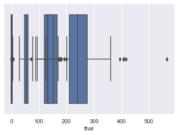

```python
sns.boxplot(x=df['age'])
sns.boxplot(x=df['sex'])
sns.boxplot(x=df['cp'])
sns.boxplot(x=df['trestbps']) #Some outliers are observed in 'trtbps'. They will be removed later
sns.boxplot(x=df['chol']) #Some outliers are observed in 'chol'. They will be removed later
sns.boxplot(x=df['fbs'])
sns.boxplot(x=df['restecg'])
sns.boxplot(x=df['thalach']) #Outliers present in thalachh
sns.boxplot(x=df['exang'])
sns.boxplot(x=df['oldpeak']) #Outliers are present in 'OldPeak'
sns.boxplot(x=df['slope'])
sns.boxplot(x=df['ca']) #Outliers are present in 'ca'
sns.boxplot(x=df['thal'])
```

The Outliers are removed using two methods,

1. Inter-Quartile Range and
2. Z-score

### b. Removing outliers using Inter-Quartile Range

```python
#Find the InterQuartile Range
Q1 = df.quantile(0.25)
Q3 = df.quantile(0.75)
IQR = Q3-Q1
print('*********** InterQuartile Range ***********')
print(IQR)

# Remove the outliers using IQR
df1 = df[~((df<(Q1-1.5*IQR))|(df>(Q3+1.5*IQR))).any(axis=1)]
df1.shape
```

```
*********** InterQuartile Range ***********
age         13.00
sex          1.00
cp           2.00
trestbps    20.00
chol        63.75
fbs          0.00
restecg      1.00
thalach     32.75
exang        1.00
oldpeak      1.60
slope        1.00
ca           1.00
thal         1.00
target       1.00
dtype: float64
```

```
(228, 14)
```

# 5. Data visualisation

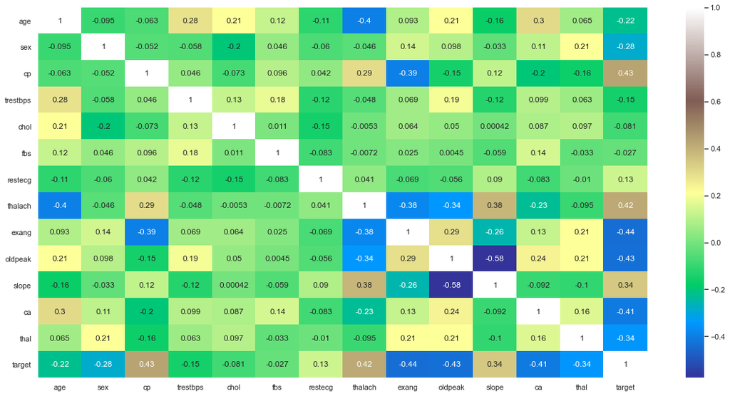

```python
plt.figure(figsize=(20,10))
sns.heatmap(df.corr(), annot=True, cmap='terrain')
```

There is a positive correlation between target and cp, thalach, slope and a Negative correlation between target and sex, exang, ca, thal, oldpeak

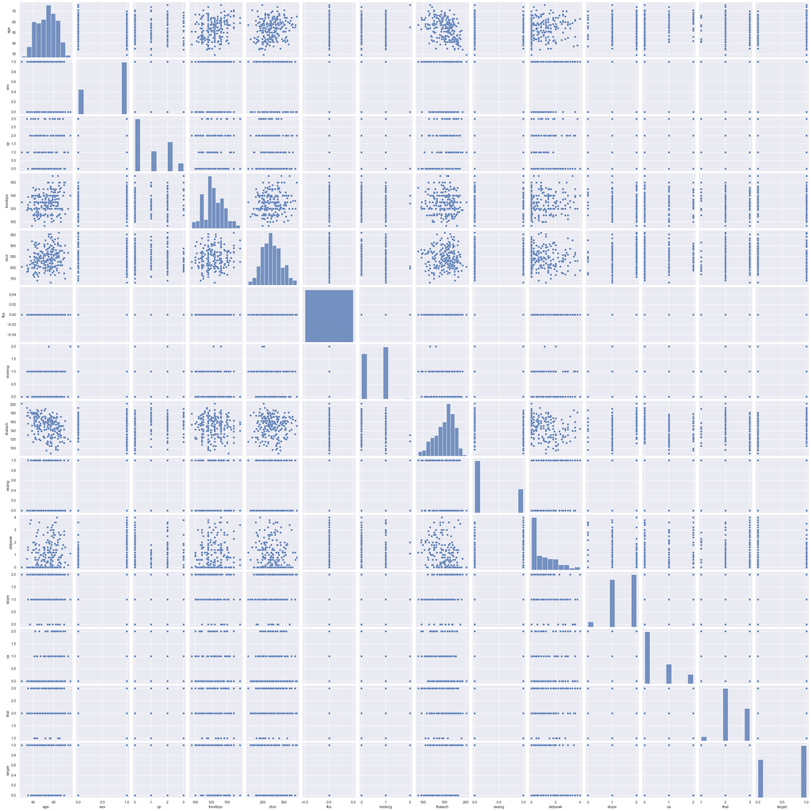

```python
sns.pairplot(data=df1)
```

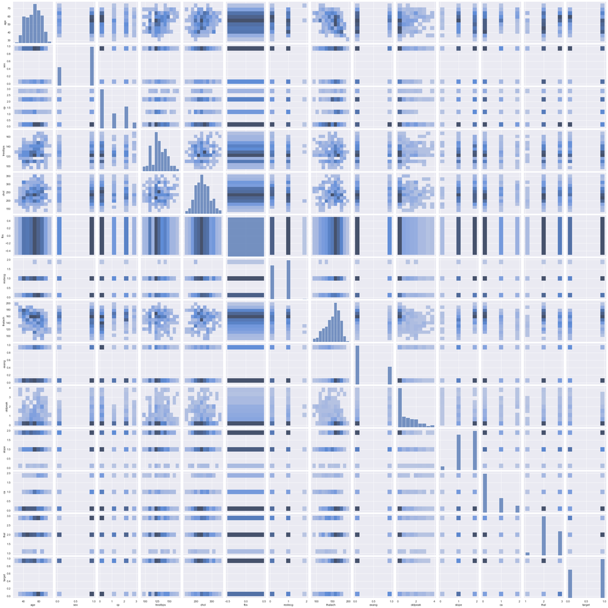

```python
sns.pairplot(data=df1, kind="hist")
```

To visualize the relationship between different features and figure out any linear relation between them we use PAIRPLOTS.

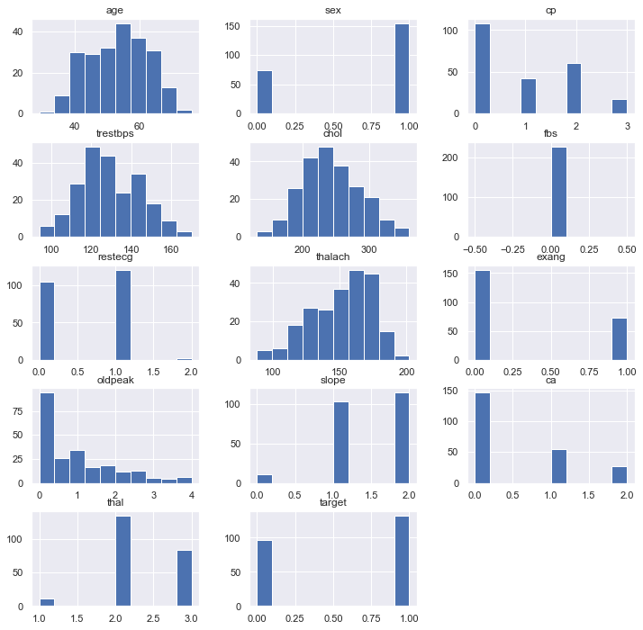

```python
# with Histograms we can see the shape of each feature and provides the count of number of observations in each bin.
df1.hist(figsize=(12,12), layout=(5,3));
```

### Box and whiskers plots:

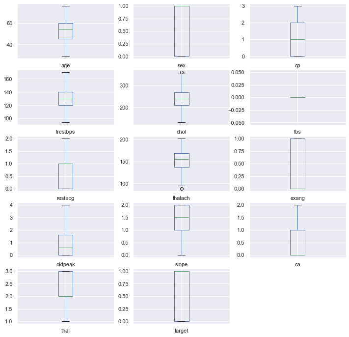

```python
df1.plot(kind='box', subplots=True, layout=(5,3), figsize=(12,12))
plt.show()
```

Box and Whiskers plot are useful to find out outliers in our data. If we have more outliers we will have to remove them or fix them otherwise they will become as noise for the training data.

#### Visualize the features and their relation with the target (Heart Disease or No Heart Disease)

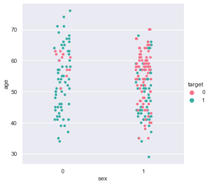

```python
sns.catplot(data=df1, x='sex', y='age', hue='target', palette='husl')
```

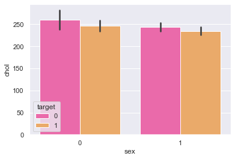

```python
sns.barplot(data=df1, x='sex', y='chol', hue='target', palette='spring')
```

```python
df1['sex'].value_counts()
```

```
1    154
0     74
Name: sex, dtype: int64
```

There are 154 males and 74 females in our data

### Chest pain type

```python
df1['cp'].value_counts()
```

```
0    108
2     61
1     42
3     17
Name: cp, dtype: int64
```

There 4 values of chest pain, ranges from 0 to 3

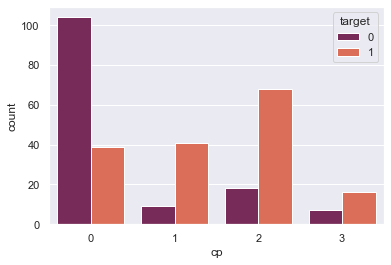

```python
sns.countplot(x='cp', hue='target', data=df, palette='rocket')
```

### Cross tables:

```python
gen = pd.crosstab(df1['sex'], df['target'])
print(gen)
```

```
target   0   1
sex
0       12  62
1       84  70
```

# 6. Preparing the data for model

BEFORE SCALING DATA:

```python
df1.head()
```

|  | age | sex | cp | trestbps | chol | fbs | restecg | thalach | exang | oldpeak | slope | ca | thal | target |
| --- | --- | --- | --- | --- | --- | --- | --- | --- | --- | --- | --- | --- | --- | --- |
| 1 | 37 | 1 | 2 | 130 | 250 | 0 | 1 | 187 | 0 | 3.5 | 0 | 0 | 2 | 1 |
| 2 | 41 | 0 | 1 | 130 | 204 | 0 | 0 | 172 | 0 | 1.4 | 2 | 0 | 2 | 1 |
| 3 | 56 | 1 | 1 | 120 | 236 | 0 | 1 | 178 | 0 | 0.8 | 2 | 0 | 2 | 1 |
| 4 | 57 | 0 | 0 | 120 | 354 | 0 | 1 | 163 | 1 | 0.6 | 2 | 0 | 2 | 1 |
| 5 | 57 | 1 | 0 | 140 | 192 | 0 | 1 | 148 | 0 | 0.4 | 1 | 0 | 1 | 1 |

### a. Scaling the data:

```python
from sklearn.model_selection import train_test_split
from sklearn.preprocessing import StandardScaler
StandardScaler = StandardScaler()
columns_to_scale = ['age', 'trestbps', 'chol', 'thalach', 'oldpeak']
df[columns_to_scale] = StandardScaler.fit_transform(df[columns_to_scale])
```

```python
df1.head()
```

|  | age | sex | cp | trestbps | chol | fbs | restecg | thalach | exang | oldpeak | slope | ca | thal | target |
| --- | --- | --- | --- | --- | --- | --- | --- | --- | --- | --- | --- | --- | --- | --- |
| 1 | 37 | 1 | 2 | 130 | 250 | 0 | 1 | 187 | 0 | 3.5 | 0 | 0 | 2 | 1 |
| 2 | 41 | 0 | 1 | 130 | 204 | 0 | 0 | 172 | 0 | 1.4 | 2 | 0 | 2 | 1 |
| 3 | 56 | 1 | 1 | 120 | 236 | 0 | 1 | 178 | 0 | 0.8 | 2 | 0 | 2 | 1 |
| 4 | 57 | 0 | 0 | 120 | 354 | 0 | 1 | 163 | 1 | 0.6 | 2 | 0 | 2 | 1 |
| 5 | 57 | 1 | 0 | 140 | 192 | 0 | 1 | 148 | 0 | 0.4 | 1 | 0 | 1 | 1 |

```python
#We will divide our dataset into training data and test data. 70% of the data were used as training and the remaining 30% will be used for testing.
x = df1.drop("target", axis=1)
y = df1["target"]
x_train,x_test,y_train,y_test = train_test_split(x,y,test_size=0.3)
```

```python
#check sample size
print('x_train', x_train.size)
print('x_test', x_test.size)
print('y_train', y_train.size)
print('y_test', y_test.size)
```

```
x_train 2067
x_test 897
y_train 159
y_test 69
```

# 7. Fitting the Data

Applying the machine learning algorithms for predictive modelling.

### 1. Logistic Regression Classifier

```python
#Building classification models
names = ['Age', 'Sex', 'cp', 'trestbps', 'chol', 'fbs', 'restecg', 'thalachh', 'exng', 'oldpeak', 'slp', 'caa', 'thall']
#   ****************Logistic Regression*****************
logReg = LogisticRegression(random_state=0, solver='liblinear')
logReg.fit(x_train, y_train)
#Check accuracy of Logistic Regression
y_pred_logReg = logReg.predict(x_test)
#Model Accuracy
print("Accuracy of logistic regression classifier :: " ,metrics.accuracy_score(y_test,y_pred_logReg))
#Removing the features with low correlation and checking effect on accuracy of model
x_train1 = x_train.drop("fbs",axis=1)
x_train1 = x_train1.drop("trestbps", axis=1)
x_train1 = x_train1.drop("chol", axis=1)
x_train1 = x_train1.drop("restecg", axis=1)
x_test1 = x_test.drop("fbs", axis=1)
x_test1 = x_test1.drop("trestbps", axis=1)
x_test1 = x_test1.drop("chol", axis=1)
x_test1 = x_test1.drop("restecg", axis=1)
logReg1 = LogisticRegression(random_state=0, solver='liblinear').fit(x_train1,y_train)
y_pred_logReg1 = logReg1.predict(x_test1)
print("nAccuracy of logistic regression classifier after removing features:: " ,metrics.accuracy_score(y_test,y_pred_logReg1))
```

```
Accuracy of logistic regression classifier ::  0.855072463768116
nAccuracy of logistic regression classifier after removing features::  0.8695652173913043
```

### 2. Decision Tree Classifier

```python
# ***********************Decision Tree Classification***********************
decTree = DecisionTreeClassifier(max_depth=6, random_state=0)
decTree.fit(x_train,y_train)
y_pred_decTree = decTree.predict(x_test)
print("Accuracy of Decision Trees :: " , metrics.accuracy_score(y_test,y_pred_decTree))
#Remove features which have low correlation with output (fbs, trtbps, chol)
x_train_dt = x_train.drop("fbs",axis=1)
x_train_dt = x_train_dt.drop("trestbps", axis=1)
x_train_dt = x_train_dt.drop("chol", axis=1)
x_train_dt = x_train_dt.drop("age", axis=1)
x_train_dt = x_train_dt.drop("sex", axis=1)
x_test_dt = x_test.drop("fbs", axis=1)
x_test_dt = x_test_dt.drop("trestbps", axis=1)
x_test_dt = x_test_dt.drop("chol", axis=1)
x_test_dt = x_test_dt.drop("age", axis=1)
x_test_dt = x_test_dt.drop("sex", axis=1)
decTree1 = DecisionTreeClassifier(max_depth=6, random_state=0)
decTree1.fit(x_train_dt, y_train)
y_pred_dt1 = decTree1.predict(x_test_dt)
print("Accuracy of decision Tree after removing features:: ", metrics.accuracy_score(y_test,y_pred_dt1))
```

```
Accuracy of Decision Trees ::  0.7391304347826086
Accuracy of decision Tree after removing features::  0.7681159420289855
```

### 3. Random Forest Classifier

```python
# Using Random forest classifier
rf = RandomForestClassifier(n_estimators=500)
rf.fit(x_train,y_train)
y_pred_rf = rf.predict(x_test)
print("Accuracy of Random Forest Classifier :: ", metrics.accuracy_score(y_test, y_pred_rf))
#Find the score of each feature in model and drop the features with low scores
f_imp = rf.feature_importances_
for i,v in enumerate(f_imp):
    print('Feature: %s, Score: %.5f' % (names[i],v))
```

```
Accuracy of Random Forest Classifier ::  0.7971014492753623
Feature: Age, Score: 0.11355
Feature: Sex, Score: 0.03915
Feature: cp, Score: 0.11459
Feature: trestbps, Score: 0.07066
Feature: chol, Score: 0.07456
Feature: fbs, Score: 0.00000
Feature: restecg, Score: 0.01775
Feature: thalachh, Score: 0.11485
Feature: exng, Score: 0.02684
Feature: oldpeak, Score: 0.12835
Feature: slp, Score: 0.03607
Feature: caa, Score: 0.11449
Feature: thall, Score: 0.14914
```

### 4. K Nearest Neighbours Classifier

```python
#K Neighbours Classifier
knc =  KNeighborsClassifier()
knc.fit(x_train,y_train)
y_pred_knc = knc.predict(x_test)
print("Accuracy of K-Neighbours classifier :: ", metrics.accuracy_score(y_test,y_pred_knc))
```

```
Accuracy of K-Neighbours classifier ::  0.6231884057971014
```

# 8. Assessing Accuracies of each model

```python
#Models and their accuracy
print("*****************Models and their accuracy*****************")
print("Logistic Regression Classifier :: ", metrics.accuracy_score(y_test,y_pred_logReg1))
print("Decision Tree :: ", metrics.accuracy_score(y_test,y_pred_dt1))
print("Random Forest Classifier :: ", metrics.accuracy_score(y_test, y_pred_rf))
print("K Neighbours Classifier :: ", metrics.accuracy_score(y_test,y_pred_knc))
```

```
*****************Models and their accuracy*****************
Logistic Regression Classifier ::  0.8695652173913043
Decision Tree ::  0.7681159420289855
Random Forest Classifier ::  0.7971014492753623
K Neighbours Classifier ::  0.6231884057971014
```

#### Logistic Regression Classifier had the highest accuracy

# 9. Confusion Matrix

Create confusion matrix with the prediction from the model with the highest accuracy.

```python
from sklearn.metrics import confusion_matrix
cm = confusion_matrix(y_test, y_pred_logReg1)
cm
```

```
array([[17,  3],
       [ 6, 43]], dtype=int64)
```

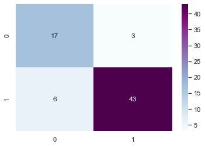

```python
sns.heatmap(cm, annot=True, cmap='BuPu')
```

```python
TP = cm[0][0]
TN = cm[1][1]
FN = cm[1][0]
FP = cm[0][1]

print('Testing accuracy:', (TP+TN) / (TP+TN+FN+FP))
```

```
Testing accuracy: 0.8695652173913043
```

```python
from sklearn.metrics import classification_report
print(classification_report(y_test,  y_pred_logReg1))
```

```
              precision    recall  f1-score   support

           0       0.74      0.85      0.79        20
           1       0.93      0.88      0.91        49

    accuracy                           0.87        69
   macro avg       0.84      0.86      0.85        69
weighted avg       0.88      0.87      0.87        69
```